# Hog Markets

# [Return to Book Homepage](http://mindymallory.github.io/PriceAnalysis/)

# Introduction

This chapter covers basic hog production, industry structure, and marketing practices, with an emphasis on how these affect hog prices. The hog market has undergone significant changes in industry organization in recent history. The industry used to be very unconcentrated with large numbers of independently owned and operated small and medium sized farms. Recently, the industry has trended toward more and more concentration in ownership, contracting and marketing agreements between owners and operators, and vertical integration in structure. This is in contrast to the beef cattle market, where ownership remains unconcentrated until the final finishing stage of produciton.

[Smithfield Videos of Production Stages](http://www.murphybrownllc.com/contract-growing/hog-production/)

# Definitions

First, we begin by introucing specialized nomenclature used in the industry.

Table 1: Defintions Related to Hog Production

| Vocabulary | Definition |
| --- | --- |
| **Various Terms** |  |
| Barrow | Neutered male hog |
| Boar | Unneutered male hog, usually kept for breeding |
| Feeder Pig | Young hog, 6-8 weeks old and 40-50lbs in weight |
| Gilt | Female hog that has not borne a litter |
| Market Hog | Adult hog for slaughter |
| Parity | Number of farrowings or litters that have been borne by a sow |
| Sow | Female hog that has borne at least one litter |
| Weanling | Weaned pig, typically 2-3 weeks of age and 10-15lbs in weight |
| Farrow | Birth of a piglet(s) |
| **Production Systems** |  |
| Farrow-to-finish | Production phase that encompasses the enture life cycle of the slaughter hog from birth (farrowing) to finishing (feeding to market weight) |
| Farrow-to-wean | Produciton phase from birth through weaning at 10-15lbs (2-3 weeks old) |
| Farrow-to-feeder | Produciton phase from birth through pigs that weigh 40-50 lb |
| Wean-to-finish | Produciton phase from just weaned pigs through market weight |
| Feeder-to-finish | Produciton phase from feeder weight pigs to market weight pigs |

# Gestation and Farrowing

The industry began using individual stalls because hogs are aggressive animals that will fight with, and often injure one another. If one animal recieved an injury that results in a bloody wound, the other hogs will become very aggressive and sometimes kill the wounded hog if the the wounded animal is not isolated. The individual stalls solve this problem, but they are quite cramped. Given the public pressure, the industry trend is to find alternative solutions to the aggression problem without relegating sows to tight quarters in the individual stalls.

Sows have 8-12 pigets per litter, and the piglets stay with their mothers for 2-3 weeks before they are weaned. Sows generally have approximately 2 litters per year and breeding sows are replaced on average after 3-4 litters.

# Feeding

Commercial hog operations keep feeder pigs in barns or ‘hog houses’ that hold hundreds of animals divided into smaller pens. Hogs are fed a ration of primarily corn and soybean meal. They require feed that contians a high quality protien and digestible amino acids, specifically lysine. Lysine is the amino acid that is most likely to be deficient in a corn-soybean diet, so it is usually supplemented. With the rise of ethanol production, distillers dried grains are utilized for both calories and protien, but not usually at higher than 30% of the ration. Utilizing higher proportions of distillers grains causes the carcass fat to be too soft.

[Images of Hog Houses](https://www.google.com/search?q=hog+houses&espv=2&biw=1920&bih=1075&source=lnms&tbm=isch&sa=X&ved=0CAYQ_AUoAWoVChMIiLHMk_mayQIVBtgeCh3Jyweb)

# Waste Management

Since a large number of hogs are housed together in close confinement, special systems to manage the waste are employed. Usually, the floors of the hog houses are slatted so the manure falls through the floor to a temporary chamber below. The waste is continually pumped to waste management lagoons located near the hog house(s).

# Geography of Hog Production

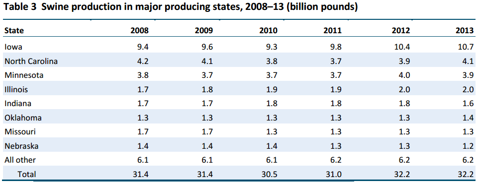

Figure 1: Top 8 Hog Producing States in 2013

Figure 2 show hog and pig sales as a percent of agricultural sales.

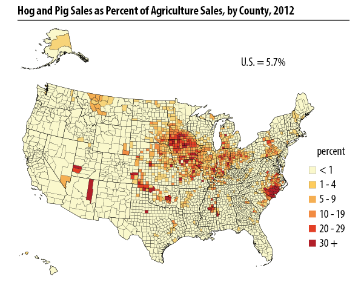

Figure 2: Hog and Pig Sales as a percent of Agricultural Sales

[See some Hog Production Operations](https://www.google.com/maps/place/Hardin+County,+IA/@42.3833668,-93.3907209,60627m/data=!3m2!1e3!4b1!4m2!3m1!1s0x87ee2ed39f2db5df:0x67a785cf003d5369!6m1!1e1)

# Industry Structure

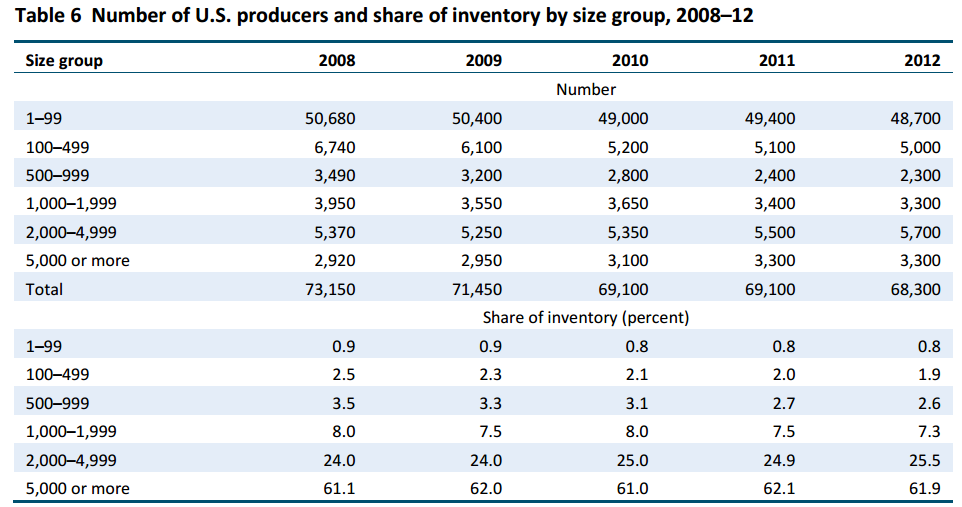

Figure 3: Number of U.S. Producers and Share of Inventory, 2008-2012

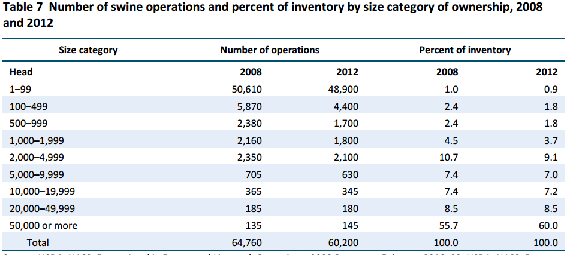

Figure 4: Number of Operations and Percent of Inventory, 2008-2012

Grower operators have trended toward specializing shorter stages of the production process. For example gestation, farrowing, and weaning versus nursery or weanling feeders, versus finishing operations. Growers are typically responsible for financing the facilities and the owner, who is often a large multinational firm will provide the animals, feed, vetrenary and other expenses.

# Price Determination

Although the number of cash sales has declined, forward contract prices and marketing agreements between contract growers and operators are often based on a formula with cash sales as a baseline. The majority of hogs are sold based on carcass quality characteristics, and not solely based on weight.

[Prices from Livestock Marketing Information Center](http://www.lmic.info/spreadsheet/prices-and-production)

[USDA Ag News Service Prices, via LMIC](http://www.lmic.info/quick_market_reports/hogs)

# Lean Hogs Futures

[Lean Hogs Futures Contracts on the CME](http://www.cmegroup.com/trading/agricultural/livestock/lean-hogs.html)

# Why only one Contract Instead of Two like Feeder and Live Cattle?

Industry consolidation has left few firms needing to hedge risk. Futures contracts are usually successful when there are a large number of firms who have a hedging need. Only then does the futures market attract speculators who provide liquidity to the market and active trading.

Also, vertical integration of the industry means that if firms can hedge the risk of their market weight hogs, that translates all along the supply chain. Unlike cattle markets where feedlots both need to buy feeder cattle and sell fattened cattle. Hog producer can hedge market hogs with the lean hogs contract and input costs with corn and soybean meal futures contracts. No second livestock contract is needed.

## Demise of the Frozen Pork Belly Futures Contracts

Until recently (2011), there existed a futures contract in frozen pork bellies.

[Pork belly images](https://www.google.com/search?q=pork+belly&biw=1920&bih=1075&noj=1&source=lnms&tbm=isch&sa=X&ved=0CAgQ_AUoAmoVChMIhbO55IqdyQIVDNUeCh0_owNp)

Concentration in the hog industry reduced the need for the pork belly contract in part. Also, an increased trend toward year-round consumption of bacon and production of pork reduced the need to store frozen pork bellies.

Refrences